# Capstone Project: Create a Customer Segmentation Report for Arvato Financial Services

In this project, I have analyzed demographics data for customers of a mail-order sales company in Germany, comparing it against demographics information for the general population. I have used unsupervised learning techniques to perform customer segmentation, identifying the parts of the population that best describe the core customer base of the company. Then,i use a model to predict which individuals are most likely to convert into becoming customers for the company. The data has been provided by our partners at Bertelsmann Arvato Analytics, and represents a real-life data science task.

```python
# import libraries here; add more as necessary
import numpy as np
import time
import pandas as pd
import matplotlib.pyplot as plt
import seaborn as sns
from sklearn.preprocessing import Imputer
from sklearn.cluster import KMeans
from sklearn.preprocessing import StandardScaler
from sklearn.decomposition import PCA
# magic word for producing visualizations in notebook
%matplotlib inline
```

## Part 0: Get to Know the Data

Each row of the demographics files represents a single person, but also includes information outside of individuals, including information about their household, building, and neighborhood.

```python
# load in the data
azdias = pd.read_csv('../../data/Term2/capstone/arvato_data/Udacity_AZDIAS_052018.csv', sep=';')
customers = pd.read_csv('../../data/Term2/capstone/arvato_data/Udacity_CUSTOMERS_052018.csv', sep=';')
```

```python
feat_info = pd.read_excel('DIAS Attributes - Values 2017.xlsx')
del feat_info['Unnamed: 0']
```

```python
feat_info.ffill(inplace=True)
```

```python
feat_info
```

```python
feat_list = feat_info['Attribute'].unique()
```

```python
# should be an empty array
diff_not_in_feat = list(set(feat_list) - set(azdias))
print('Features in feat_list that are not in azdias:')
print(len(diff_not_in_feat))
print(diff_not_in_feat)
print('-------------')

# features that are not in feat_info (no information regarding type)
diff_not_in_azdias = list(set(azdias) - set(feat_list))
print('Features in azdias that are not in feat_list:')
print(len(diff_not_in_azdias))
print(diff_not_in_azdias)
```

```python
len(drop_columns)
```

Dropping some Features in azdias that are not in feat_list because So what will i do with the features which does not provide any details so i am just removing them

```python
azdias.drop(['D19_KINDERARTIKEL', 'D19_LEBENSMITTEL', 'D19_NAHRUNGSERGAENZUNG', 'D19_BUCH_CD', 'CJT_KATALOGNUTZER', 'KONSUMZELLE', 'CJT_TYP_6', 'D19_LOTTO', 'D19_VERSI_OFFLINE_DATUM', 'D19_WEIN_FEINKOST', 'D19_VERSAND_REST', 'ALTER_KIND3', 'KK_KUNDENTYP', 'D19_GARTEN', 'D19_FREIZEIT', 'D19_TECHNIK', 'D19_BANKEN_LOKAL', 'D19_TIERARTIKEL', 'D19_VERSI_ONLINE_DATUM', 'D19_BEKLEIDUNG_GEH', 'D19_SAMMELARTIKEL', 'CJT_TYP_1', 'D19_VERSI_ONLINE_QUOTE_12', 'ARBEIT', 'KBA13_ANTG2', 'ANZ_KINDER', 'D19_TELKO_REST', 'ALTER_KIND4', 'D19_TELKO_ONLINE_QUOTE_12', 'HH_DELTA_FLAG', 'KBA13_KMH_210', 'D19_RATGEBER', 'CJT_TYP_3', 'D19_VERSI_DATUM', 'UNGLEICHENN_FLAG', 'VERDICHTUNGSRAUM', 'STRUKTURTYP', 'LNR', 'VK_DHT4A', 'D19_HAUS_DEKO', 'D19_DIGIT_SERV', 'D19_VOLLSORTIMENT', 'D19_DROGERIEARTIKEL', 'EINGEFUEGT_AM', 'RT_SCHNAEPPCHEN', 'ALTER_KIND2', 'D19_KONSUMTYP_MAX', 'GEMEINDETYP', 'KBA13_ANTG4', 'D19_SOZIALES', 'D19_BANKEN_GROSS', 'D19_HANDWERK', 'KOMBIALTER', 'KBA13_ANTG3', 'D19_BILDUNG', 'KBA13_ANTG1', 'AKT_DAT_KL', 'D19_VERSICHERUNGEN', 'KBA13_CCM_1401_2500', 'VHN', 'KBA13_GBZ', 'MOBI_RASTER', 'D19_BANKEN_REST', 'VK_DISTANZ', 'VHA', 'KBA13_HHZ', 'CJT_TYP_2', 'D19_TELKO_MOBILE', 'D19_ENERGIE', 'D19_SONSTIGE', 'EINGEZOGENAM_HH_JAHR', 'D19_REISEN', 'D19_BANKEN_DIREKT', 'CJT_TYP_5', 'VK_ZG11', 'ALTERSKATEGORIE_FEIN', 'UMFELD_ALT', 'CAMEO_INTL_2015', 'ALTER_KIND1', 'SOHO_KZ', 'D19_BIO_OEKO', 'D19_KOSMETIK', 'D19_BEKLEIDUNG_REST', 'RT_KEIN_ANREIZ', 'D19_SCHUHE', 'RT_UEBERGROESSE', 'FIRMENDICHTE', 'ANZ_STATISTISCHE_HAUSHALTE', 'UMFELD_JUNG', 'EXTSEL992', 'DSL_FLAG', 'CJT_TYP_4', 'D19_LETZTER_KAUF_BRANCHE', 'KBA13_BAUMAX'],axis=1,inplace=True)
```

```python
customers.drop(['D19_KINDERARTIKEL', 'D19_LEBENSMITTEL', 'D19_NAHRUNGSERGAENZUNG', 'D19_BUCH_CD', 'CJT_KATALOGNUTZER', 'KONSUMZELLE', 'CJT_TYP_6', 'D19_LOTTO', 'D19_VERSI_OFFLINE_DATUM', 'D19_WEIN_FEINKOST', 'D19_VERSAND_REST', 'ALTER_KIND3', 'KK_KUNDENTYP', 'D19_GARTEN', 'D19_FREIZEIT', 'D19_TECHNIK', 'D19_BANKEN_LOKAL', 'D19_TIERARTIKEL', 'D19_VERSI_ONLINE_DATUM', 'D19_BEKLEIDUNG_GEH', 'D19_SAMMELARTIKEL', 'CJT_TYP_1', 'D19_VERSI_ONLINE_QUOTE_12', 'ARBEIT', 'KBA13_ANTG2', 'ANZ_KINDER', 'D19_TELKO_REST', 'ALTER_KIND4', 'D19_TELKO_ONLINE_QUOTE_12', 'HH_DELTA_FLAG', 'KBA13_KMH_210', 'D19_RATGEBER', 'CJT_TYP_3', 'D19_VERSI_DATUM', 'UNGLEICHENN_FLAG', 'VERDICHTUNGSRAUM', 'STRUKTURTYP', 'LNR', 'VK_DHT4A', 'D19_HAUS_DEKO', 'D19_DIGIT_SERV', 'D19_VOLLSORTIMENT', 'D19_DROGERIEARTIKEL', 'EINGEFUEGT_AM', 'RT_SCHNAEPPCHEN', 'ALTER_KIND2', 'D19_KONSUMTYP_MAX', 'GEMEINDETYP', 'KBA13_ANTG4', 'D19_SOZIALES', 'D19_BANKEN_GROSS', 'D19_HANDWERK', 'KOMBIALTER', 'KBA13_ANTG3', 'D19_BILDUNG', 'KBA13_ANTG1', 'AKT_DAT_KL', 'D19_VERSICHERUNGEN', 'KBA13_CCM_1401_2500', 'VHN', 'KBA13_GBZ', 'MOBI_RASTER', 'D19_BANKEN_REST', 'VK_DISTANZ', 'VHA', 'KBA13_HHZ', 'CJT_TYP_2', 'D19_TELKO_MOBILE', 'D19_ENERGIE', 'D19_SONSTIGE', 'EINGEZOGENAM_HH_JAHR', 'D19_REISEN', 'D19_BANKEN_DIREKT', 'CJT_TYP_5', 'VK_ZG11', 'ALTERSKATEGORIE_FEIN', 'UMFELD_ALT', 'CAMEO_INTL_2015', 'ALTER_KIND1', 'SOHO_KZ', 'D19_BIO_OEKO', 'D19_KOSMETIK', 'D19_BEKLEIDUNG_REST', 'RT_KEIN_ANREIZ', 'D19_SCHUHE', 'RT_UEBERGROESSE', 'FIRMENDICHTE', 'ANZ_STATISTISCHE_HAUSHALTE', 'UMFELD_JUNG', 'EXTSEL992', 'DSL_FLAG', 'CJT_TYP_4', 'D19_LETZTER_KAUF_BRANCHE', 'KBA13_BAUMAX'],axis=1,inplace=True)
```

```python
customers.drop(['PRODUCT_GROUP', 'ONLINE_PURCHASE', 'CUSTOMER_GROUP'],axis=1,inplace=True)
```

```python
#looking for nans
column_nans = azdias.isnull().mean()
plt.hist(column_nans, bins = np.arange(0,1+.05,.05))
plt.ylabel('# of features')
plt.xlabel('prop. of missing values')
```

```python
unknowns = []
for attribute in feat_info['Attribute'].unique():
    _ = feat_info.loc[feat_info['Attribute'] == attribute, 'Value'].astype(str).str.cat(sep=',')
    _ = _.split(',')
    unknowns.append(_)

unknowns = pd.concat([pd.Series(feat_info['Attribute'].unique()), pd.Series(unknowns)], axis=1)
unknowns.columns = ['attribute', 'missing_or_unknown']
print(unknowns)
```

```python
start = time.time()

for row in unknowns['attribute']:
    print(row)
    if row in azdias.columns:
        na_map = unknowns.loc[unknowns['attribute'] == row, 'missing_or_unknown'].iloc[0]
        na_idx = azdias.loc[:, row].isin(na_map)
        azdias.loc[na_idx, row] = np.NaN
    else:
        continue

end = time.time()
elapsed = end - start
elapsed
```

```python
column_nans = azdias.isnull().mean()
plt.hist(column_nans, bins = np.arange(0,1+.05,.05))
plt.ylabel('# of features')
plt.xlabel('prop. of missing values')
```

```python
col_drops = column_nans[columns_nans>0.2].index
```

```python
col_drops
```

```python
col_drops = ['AGER_TYP', 'ALTER_HH', 'D19_BANKEN_ANZ_12', 'D19_BANKEN_ANZ_24',
             'D19_BANKEN_ONLINE_QUOTE_12', 'D19_GESAMT_ANZ_12', 'D19_GESAMT_ANZ_24',
             'D19_GESAMT_ONLINE_QUOTE_12', 'D19_KONSUMTYP', 'D19_TELKO_ANZ_12',
             'D19_TELKO_ANZ_24', 'D19_VERSAND_ANZ_12', 'D19_VERSAND_ANZ_24',
             'D19_VERSAND_ONLINE_QUOTE_12', 'D19_VERSI_ANZ_12', 'D19_VERSI_ANZ_24',
             'GREEN_AVANTGARDE', 'KBA05_AUTOQUOT', 'KBA05_BAUMAX', 'KONSUMNAEHE',
             'LP_FAMILIE_FEIN', 'LP_FAMILIE_GROB', 'LP_STATUS_FEIN',
             'LP_STATUS_GROB', 'MOBI_REGIO', 'PLZ8_BAUMAX', 'RELAT_AB', 'TITEL_KZ']
```

```python
azdias.drop(col_drops,axis=1,inplace=True)
```

Correlation Coefficient = 0.8: A fairly strong positive relationship.

Correlation Coefficient = 0.6: A moderate positive relationship

So, i have choosen a value of 0.7

```python
# find correlation matrix
corr_matrix = azdias.corr().abs()
upper_limit = corr_matrix.where(np.triu(np.ones(corr_matrix.shape), k=1).astype(np.bool))
# identify columns to drop based on threshold limit
drop_columns = [column for column in upper_limit.columns if any(upper_limit[column] > .7)]
```

```python
drop_columns = ['D19_BANKEN_ONLINE_DATUM', 'D19_GESAMT_ONLINE_DATUM', 'D19_VERSAND_DATUM', 'D19_VERSAND_OFFLINE_DATUM', 'D19_VERSAND_ONLINE_DATUM',
 'FINANZ_SPARER', 'FINANZ_UNAUFFAELLIGER', 'FINANZ_VORSORGER', 'INNENSTADT', 'KBA05_KRSHERST1', 'KBA05_KRSHERST2', 'KBA05_KRSHERST3', 'KBA05_KW2',
 'KBA05_SEG2', 'KBA05_SEG5', 'KBA05_SEG9', 'KBA05_ZUL4', 'KBA13_BJ_2000', 'KBA13_BJ_2006', 'KBA13_HALTER_25', 'KBA13_HALTER_30', 'KBA13_HALTER_35', 'KBA13_HALTER_40', 'KBA13_HALTER_50', 'KBA13_HALTER_55', 'KBA13_HALTER_66', 'KBA13_HERST_BMW_BENZ',
 'KBA13_HERST_SONST', 'KBA13_KMH_140', 'KBA13_KMH_211', 'KBA13_KMH_250', 'KBA13_KRSHERST_FORD_OPEL', 'KBA13_KW_30', 'KBA13_KW_61_120', 'KBA13_MERCEDES', 'KBA13_OPEL', 'KBA13_SEG_KLEINWAGEN',
 'KBA13_SEG_MINIVANS', 'KBA13_SEG_VAN', 'KBA13_SITZE_5', 'KBA13_VORB_1', 'KBA13_VORB_2', 'KBA13_VW', 'LP_LEBENSPHASE_FEIN',
 'LP_LEBENSPHASE_GROB', 'ONLINE_AFFINITAET', 'ORTSGR_KLS9', 'PLZ8_ANTG3', 'PLZ8_ANTG4', 'PLZ8_GBZ', 'PLZ8_HHZ', 'PRAEGENDE_JUGENDJAHRE',
 'REGIOTYP', 'SEMIO_KAEM', 'SEMIO_VERT', 'ANREDE_KZ', 'ALTERSKATEGORIE_GROB']
```

```python
azdias.drop(drop_columns,axis=1,inplace=True)
```

```python
azdias.shape
```

```python
rows_nans = azdias.isnull().mean(axis=1)
plt.hist(rows_nans, bins = np.arange(0,1+.05,.05))
plt.ylabel('# of features')
plt.xlabel('prop. of missing values')
```

```python
azdias.shape
```

```python
azdias=azdias.fillna(azdias.mode().iloc[0])
```

```python
azdias[azdias.duplicated()]
```

```python
azdias.drop_duplicates(inplace=True)
```

```python
azdias.shape
```

```python
#looking for nans
column_nans = azdias.isnull().mean()
plt.hist(column_nans, bins = np.arange(0,1+.05,.05))
plt.ylabel('# of features')
plt.xlabel('prop. of missing values')
```

```python
#looking for nans
rows_nans = azdias.isnull().mean(axis=1)
plt.hist(rows_nans)
plt.ylabel('# of features')
plt.xlabel('prop. of missing values')
```

```python
drop_col = column_nans[column_nans>0.2].index
```

```python
drop_col
```

```python
azdias.drop(drop_col,axis=1,inplace=True)
```

```python
azdias.shape
```

```python
# finding numeric and categorical columns
Numeric_columns=azdias.select_dtypes(include=np.number).columns.tolist()
categorical_col=set(azdias.columns).difference(set(Numeric_columns))
# numeric cols to numeric
print(categorical_col)
```

```python
azdias['CAMEO_DEU_2015'].unique()
```

```python
azdias['CAMEO_DEU_2015'].value_counts()
```

```python
azdias.drop('CAMEO_DEU_2015',inplace=True,axis=1)
```

```python
azdias['CAMEO_DEUG_2015'].unique()
```

```python
azdias['CAMEO_DEUG_2015'].value_counts()
```

```python
azdias[['CAMEO_DEUG_2015']] = azdias[['CAMEO_DEUG_2015']].replace(['X'],np.NaN)
```

```python
azdias[['CAMEO_DEUG_2015']] = azdias[['CAMEO_DEUG_2015']].replace(['XX','X'],np.NaN)
```

```python
azdias['CAMEO_DEUG_2015'].value_counts()
```

```python
azdias=pd.get_dummies(azdias)
```

```python
azdias.shape
```

```python
Numeric_columns=azdias.select_dtypes(include=np.number).columns.tolist()
categorical_col=set(azdias.columns).difference(set(Numeric_columns))
#numeric cols to numeric
print(categorical_col)
```

## Checkpoint

```python
# import libraries
import numpy as np
import time
import pandas as pd
import matplotlib.pyplot as plt
import seaborn as sns
from sklearn.preprocessing import Imputer
from sklearn.cluster import KMeans
from sklearn.preprocessing import StandardScaler
from sklearn.decomposition import PCA
# magic word for producing visualizations in notebook
%matplotlib inline
# load in the data
azdias = pd.read_csv('../../data/Term2/capstone/arvato_data/Udacity_AZDIAS_052018.csv', sep=';')
```

```python
customers = pd.read_csv('../../data/Term2/capstone/arvato_data/Udacity_CUSTOMERS_052018.csv', sep=';')
```

```python
azdias.shape
```

```
(891221, 366)
```

```python
drop_columns = ['D19_KINDERARTIKEL', 'D19_LEBENSMITTEL', 'D19_NAHRUNGSERGAENZUNG',
                'D19_BUCH_CD', 'CJT_KATALOGNUTZER', 'KONSUMZELLE', 'CJT_TYP_6',
                'D19_LOTTO', 'D19_VERSI_OFFLINE_DATUM', 'D19_WEIN_FEINKOST', 'D19_VERSAND_REST',
                'ALTER_KIND3', 'KK_KUNDENTYP', 'D19_GARTEN', 'D19_FREIZEIT', 'D19_TECHNIK',
                'D19_BANKEN_LOKAL', 'D19_TIERARTIKEL', 'D19_VERSI_ONLINE_DATUM', 'D19_BEKLEIDUNG_GEH',
                'D19_SAMMELARTIKEL', 'CJT_TYP_1', 'D19_VERSI_ONLINE_QUOTE_12', 'ARBEIT', 'KBA13_ANTG2',
                'ANZ_KINDER', 'D19_TELKO_REST', 'ALTER_KIND4', 'D19_TELKO_ONLINE_QUOTE_12', 'HH_DELTA_FLAG',
                'KBA13_KMH_210', 'D19_RATGEBER', 'CJT_TYP_3', 'D19_VERSI_DATUM', 'UNGLEICHENN_FLAG',
                'VERDICHTUNGSRAUM', 'STRUKTURTYP', 'LNR', 'VK_DHT4A', 'D19_HAUS_DEKO', 'D19_DIGIT_SERV',
                'D19_VOLLSORTIMENT', 'D19_DROGERIEARTIKEL', 'EINGEFUEGT_AM', 'RT_SCHNAEPPCHEN', 'ALTER_KIND2',
                'D19_KONSUMTYP_MAX', 'GEMEINDETYP', 'KBA13_ANTG4', 'D19_SOZIALES', 'D19_BANKEN_GROSS',
                'D19_HANDWERK', 'KOMBIALTER', 'KBA13_ANTG3', 'D19_BILDUNG', 'KBA13_ANTG1', 'AKT_DAT_KL',
                'D19_VERSICHERUNGEN', 'KBA13_CCM_1401_2500', 'VHN', 'KBA13_GBZ', 'MOBI_RASTER',
                'D19_BANKEN_REST', 'VK_DISTANZ', 'VHA', 'KBA13_HHZ', 'CJT_TYP_2', 'D19_TELKO_MOBILE',
                'D19_ENERGIE', 'D19_SONSTIGE', 'EINGEZOGENAM_HH_JAHR', 'D19_REISEN', 'D19_BANKEN_DIREKT',
                'CJT_TYP_5', 'VK_ZG11', 'ALTERSKATEGORIE_FEIN', 'UMFELD_ALT', 'CAMEO_INTL_2015', 'ALTER_KIND1',
                'SOHO_KZ', 'D19_BIO_OEKO', 'D19_KOSMETIK', 'D19_BEKLEIDUNG_REST', 'RT_KEIN_ANREIZ', 'D19_SCHUHE',
                'RT_UEBERGROESSE', 'FIRMENDICHTE', 'ANZ_STATISTISCHE_HAUSHALTE', 'UMFELD_JUNG', 'EXTSEL992',
                'DSL_FLAG', 'CJT_TYP_4', 'D19_LETZTER_KAUF_BRANCHE', 'KBA13_BAUMAX',
                'AGER_TYP', 'ALTER_HH', 'D19_BANKEN_ANZ_12', 'D19_BANKEN_ANZ_24','D19_BANKEN_ONLINE_QUOTE_12',
                'D19_GESAMT_ANZ_12', 'D19_GESAMT_ANZ_24','D19_GESAMT_ONLINE_QUOTE_12', 'D19_KONSUMTYP',
                'D19_TELKO_ANZ_12','D19_TELKO_ANZ_24', 'D19_VERSAND_ANZ_12', 'D19_VERSAND_ANZ_24',
                'D19_VERSAND_ONLINE_QUOTE_12', 'D19_VERSI_ANZ_12','D19_VERSI_ANZ_24','GREEN_AVANTGARDE',
                'KBA05_AUTOQUOT', 'KBA05_BAUMAX', 'KONSUMNAEHE','LP_FAMILIE_FEIN', 'LP_FAMILIE_GROB',
                'LP_STATUS_FEIN','LP_STATUS_GROB', 'MOBI_REGIO', 'PLZ8_BAUMAX', 'RELAT_AB', 'TITEL_KZ',
                'D19_BANKEN_ONLINE_DATUM', 'D19_GESAMT_ONLINE_DATUM', 'D19_VERSAND_DATUM', 'D19_VERSAND_OFFLINE_DATUM',
                'D19_VERSAND_ONLINE_DATUM', 'FINANZ_SPARER',
                'FINANZ_UNAUFFAELLIGER', 'FINANZ_VORSORGER', 'INNENSTADT', 'KBA05_KRSHERST1', 'KBA05_KRSHERST2',
                'KBA05_KRSHERST3', 'KBA05_KW2', 'KBA05_SEG2', 'KBA05_SEG5', 'KBA05_SEG9', 'KBA05_ZUL4',
                'KBA13_BJ_2000', 'KBA13_BJ_2006', 'KBA13_HALTER_25', 'KBA13_HALTER_30', 'KBA13_HALTER_35',
                'KBA13_HALTER_40', 'KBA13_HALTER_50', 'KBA13_HALTER_55', 'KBA13_HALTER_66', 'KBA13_HERST_BMW_BENZ',
                'KBA13_HERST_SONST', 'KBA13_KMH_140', 'KBA13_KMH_211', 'KBA13_KMH_250', 'KBA13_KRSHERST_FORD_OPEL',
                'KBA13_KW_30', 'KBA13_KW_61_120', 'KBA13_MERCEDES', 'KBA13_OPEL', 'KBA13_SEG_KLEINWAGEN',
                'KBA13_SEG_MINIVANS', 'KBA13_SEG_VAN', 'KBA13_SITZE_5', 'KBA13_VORB_1', 'KBA13_VORB_2',
                'KBA13_VW', 'LP_LEBENSPHASE_FEIN', 'LP_LEBENSPHASE_GROB', 'ONLINE_AFFINITAET', 'ORTSGR_KLS9',
                'PLZ8_ANTG3', 'PLZ8_ANTG4', 'PLZ8_GBZ', 'PLZ8_HHZ', 'PRAEGENDE_JUGENDJAHRE','REGIOTYP',
                'SEMIO_KAEM', 'SEMIO_VERT', 'ANREDE_KZ', 'ALTERSKATEGORIE_GROB','BALLRAUM',
                'CJT_GESAMTTYP', 'D19_BANKEN_DATUM','D19_BANKEN_OFFLINE_DATUM','CAMEO_DEU_2015']

azdias.drop(drop_columns,inplace=True,axis=1)
#looking for nans
rows_nans = azdias.isnull().mean(axis=1);
drop_rows = rows_nans[rows_nans>=0.2].index
azdias.drop(drop_rows,axis=0,inplace=True)
azdias[['CAMEO_DEUG_2015']] = azdias[['CAMEO_DEUG_2015']].replace(['XX','X'],np.NaN)
azdias['CAMEO_DEUG_2015']=azdias['CAMEO_DEUG_2015'].apply(pd.to_numeric)
# finding numeric and categorical columns
Numeric_columns=azdias.select_dtypes(include=np.number).columns.tolist()
categorical_col=set(azdias.columns).difference(set(Numeric_columns))
# numeric cols to numeric
print(categorical_col)
azdias[Numeric_columns]=azdias[Numeric_columns].apply(pd.to_numeric)
azdias=azdias.fillna(azdias.mode().iloc[0])
azdias=pd.get_dummies(azdias)
# finding numeric and categorical columns
Numeric_columns=azdias.select_dtypes(include=np.number).columns.tolist()
categorical_col=set(azdias.columns).difference(set(Numeric_columns))
# numeric cols to numeric
print(categorical_col)
```

```
{'OST_WEST_KZ'}
set()
```

```python
azdias.shape
```

```
(751331, 183)
```

```
Text(0.5,0,'prop. of missing values')
```

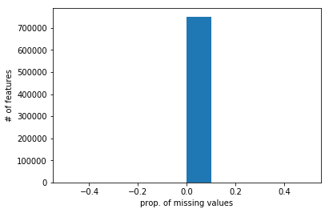

```python
#looking for nans
rows_nans = azdias.isnull().mean(axis=1)
plt.hist(rows_nans)
plt.ylabel('# of features')
plt.xlabel('prop. of missing values')
```

```
Text(0.5,0,'prop. of missing values')
```

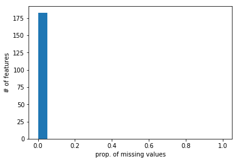

```python
#looking for nans
column_nans = azdias.isnull().mean()
plt.hist(column_nans, bins = np.arange(0,1+.05,.05))
plt.ylabel('# of features')
plt.xlabel('prop. of missing values')
```

```python
azdias.to_csv('azdias.csv')
```

```python
drop_columns =['CAMEO_DEU_2015', 'CAMEO_DEUG_2015', 'CAMEO_INTL_2015', 'D19_LETZTER_KAUF_BRANCHE', 'EINGEFUEGT_AM','OST_WEST_KZ']
 ['D19_KINDERARTIKEL', 'D19_LEBENSMITTEL', 'D19_NAHRUNGSERGAENZUNG',
                'D19_BUCH_CD', 'CJT_KATALOGNUTZER', 'KONSUMZELLE', 'CJT_TYP_6',
                'D19_LOTTO', 'D19_VERSI_OFFLINE_DATUM', 'D19_WEIN_FEINKOST', 'D19_VERSAND_REST',
                'ALTER_KIND3', 'KK_KUNDENTYP', 'D19_GARTEN', 'D19_FREIZEIT', 'D19_TECHNIK',
                'D19_BANKEN_LOKAL', 'D19_TIERARTIKEL', 'D19_VERSI_ONLINE_DATUM', 'D19_BEKLEIDUNG_GEH',
                'D19_SAMMELARTIKEL', 'CJT_TYP_1', 'D19_VERSI_ONLINE_QUOTE_12', 'ARBEIT', 'KBA13_ANTG2',
                'ANZ_KINDER', 'D19_TELKO_REST', 'ALTER_KIND4', 'D19_TELKO_ONLINE_QUOTE_12', 'HH_DELTA_FLAG',
                'KBA13_KMH_210', 'D19_RATGEBER', 'CJT_TYP_3', 'D19_VERSI_DATUM', 'UNGLEICHENN_FLAG',
                'VERDICHTUNGSRAUM', 'STRUKTURTYP', 'LNR', 'VK_DHT4A', 'D19_HAUS_DEKO', 'D19_DIGIT_SERV',
                'D19_VOLLSORTIMENT', 'D19_DROGERIEARTIKEL', 'EINGEFUEGT_AM', 'RT_SCHNAEPPCHEN', 'ALTER_KIND2',
                'D19_KONSUMTYP_MAX', 'GEMEINDETYP', 'KBA13_ANTG4', 'D19_SOZIALES', 'D19_BANKEN_GROSS',
                'D19_HANDWERK', 'KOMBIALTER', 'KBA13_ANTG3', 'D19_BILDUNG', 'KBA13_ANTG1', 'AKT_DAT_KL',
                'D19_VERSICHERUNGEN', 'KBA13_CCM_1401_2500', 'VHN', 'KBA13_GBZ', 'MOBI_RASTER',
                'D19_BANKEN_REST', 'VK_DISTANZ', 'VHA', 'KBA13_HHZ', 'CJT_TYP_2', 'D19_TELKO_MOBILE',
                'D19_ENERGIE', 'D19_SONSTIGE', 'EINGEZOGENAM_HH_JAHR', 'D19_REISEN', 'D19_BANKEN_DIREKT',
                'CJT_TYP_5', 'VK_ZG11', 'ALTERSKATEGORIE_FEIN', 'UMFELD_ALT', 'CAMEO_INTL_2015', 'ALTER_KIND1',
                'SOHO_KZ', 'D19_BIO_OEKO', 'D19_KOSMETIK', 'D19_BEKLEIDUNG_REST', 'RT_KEIN_ANREIZ', 'D19_SCHUHE',
                'RT_UEBERGROESSE', 'FIRMENDICHTE', 'ANZ_STATISTISCHE_HAUSHALTE', 'UMFELD_JUNG', 'EXTSEL992',
                'DSL_FLAG', 'CJT_TYP_4', 'D19_LETZTER_KAUF_BRANCHE', 'KBA13_BAUMAX',
                'AGER_TYP', 'ALTER_HH', 'D19_BANKEN_ANZ_12', 'D19_BANKEN_ANZ_24','D19_BANKEN_ONLINE_QUOTE_12',
                'D19_GESAMT_ANZ_12', 'D19_GESAMT_ANZ_24','D19_GESAMT_ONLINE_QUOTE_12', 'D19_KONSUMTYP',
                'D19_TELKO_ANZ_12','D19_TELKO_ANZ_24', 'D19_VERSAND_ANZ_12', 'D19_VERSAND_ANZ_24',
                'D19_VERSAND_ONLINE_QUOTE_12', 'D19_VERSI_ANZ_12','D19_VERSI_ANZ_24','GREEN_AVANTGARDE',
                'KBA05_AUTOQUOT', 'KBA05_BAUMAX', 'KONSUMNAEHE','LP_FAMILIE_FEIN', 'LP_FAMILIE_GROB',
                'LP_STATUS_FEIN','LP_STATUS_GROB', 'MOBI_REGIO', 'PLZ8_BAUMAX', 'RELAT_AB', 'TITEL_KZ',
                'D19_BANKEN_ONLINE_DATUM', 'D19_GESAMT_ONLINE_DATUM', 'D19_VERSAND_DATUM', 'D19_VERSAND_OFFLINE_DATUM',
                'D19_VERSAND_ONLINE_DATUM', 'FINANZ_SPARER',
                'FINANZ_UNAUFFAELLIGER', 'FINANZ_VORSORGER', 'INNENSTADT', 'KBA05_KRSHERST1', 'KBA05_KRSHERST2',
                'KBA05_KRSHERST3', 'KBA05_KW2', 'KBA05_SEG2', 'KBA05_SEG5', 'KBA05_SEG9', 'KBA05_ZUL4',
                'KBA13_BJ_2000', 'KBA13_BJ_2006', 'KBA13_HALTER_25', 'KBA13_HALTER_30', 'KBA13_HALTER_35',
                'KBA13_HALTER_40', 'KBA13_HALTER_50', 'KBA13_HALTER_55', 'KBA13_HALTER_66', 'KBA13_HERST_BMW_BENZ',
                'KBA13_HERST_SONST', 'KBA13_KMH_140', 'KBA13_KMH_211', 'KBA13_KMH_250', 'KBA13_KRSHERST_FORD_OPEL',
                'KBA13_KW_30', 'KBA13_KW_61_120', 'KBA13_MERCEDES', 'KBA13_OPEL', 'KBA13_SEG_KLEINWAGEN',
                'KBA13_SEG_MINIVANS', 'KBA13_SEG_VAN', 'KBA13_SITZE_5', 'KBA13_VORB_1', 'KBA13_VORB_2',
                'KBA13_VW', 'LP_LEBENSPHASE_FEIN', 'LP_LEBENSPHASE_GROB', 'ONLINE_AFFINITAET', 'ORTSGR_KLS9',
                'PLZ8_ANTG3', 'PLZ8_ANTG4', 'PLZ8_GBZ', 'PLZ8_HHZ', 'PRAEGENDE_JUGENDJAHRE','REGIOTYP',
                'SEMIO_KAEM', 'SEMIO_VERT', 'ANREDE_KZ', 'ALTERSKATEGORIE_GROB','BALLRAUM',
                'CJT_GESAMTTYP', 'D19_BANKEN_DATUM','D19_BANKEN_OFFLINE_DATUM','CAMEO_DEU_2015',
                 'CUSTOMER_GROUP', 'PRODUCT_GROUP','ONLINE_PURCHASE']
customers.drop(drop_columns,inplace=True,axis=1)
#looking for nans
rows_nans = customers.isnull().mean(axis=1);
drop_rows = rows_nans[rows_nans>=0.2].index
customers.drop(drop_rows,axis=0,inplace=True)
customers[['CAMEO_DEUG_2015']] = customers[['CAMEO_DEUG_2015']].replace(['XX','X'],np.NaN)
customers['CAMEO_DEUG_2015']=customers['CAMEO_DEUG_2015'].apply(pd.to_numeric)
# finding numeric and categorical columns
Numeric_columns=customers.select_dtypes(include=np.number).columns.tolist()
categorical_col=set(customers.columns).difference(set(Numeric_columns))
# numeric cols to numeric
print(categorical_col)
customers[Numeric_columns]=customers[Numeric_columns].apply(pd.to_numeric)
customers=customers.fillna(customers.mode().iloc[0])
customers=pd.get_dummies(customers)
# finding numeric and categorical columns
Numeric_columns=customers.select_dtypes(include=np.number).columns.tolist()
categorical_col=set(customers.columns).difference(set(Numeric_columns))
# numeric cols to numeric
print(categorical_col)
```

```
{'OST_WEST_KZ'}
set()
```

```python
customers.shape
```

```
(135144, 183)
```

```
Text(0.5,0,'prop. of missing values')
```

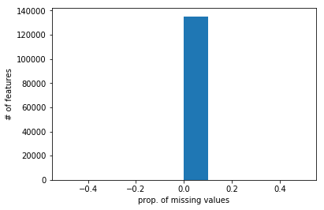

```python
#looking for nans
rows_nans = customers.isnull().mean(axis=1)
plt.hist(rows_nans)
plt.ylabel('# of features')
plt.xlabel('prop. of missing values')
```

```
Text(0.5,0,'prop. of missing values')
```

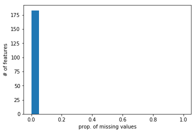

```python
#looking for nans
column_nans = azdias.isnull().mean()
plt.hist(column_nans, bins = np.arange(0,1+.05,.05))
plt.ylabel('# of features')
plt.xlabel('prop. of missing values')
```

```python
customers.to_csv('customers.csv')
```

```python
print(azdias.shape)
print(customers.shape)
```

```
(751331, 183)
(135144, 183)
```

## Part 1: Customer Segmentation Report

using unsupervised learning techniques to describe the relationship between the demographics of the company's existing customers and the general population of Germany. .

```python
azdias = pd.read_csv('azdias.csv')
```

```python
azdias.head()
```

|  | Unnamed: 0 | ANZ_HAUSHALTE_AKTIV | ANZ_HH_TITEL | ANZ_PERSONEN | ANZ_TITEL | CAMEO_DEUG_2015 | D19_GESAMT_DATUM | D19_GESAMT_OFFLINE_DATUM | D19_TELKO_DATUM | D19_TELKO_OFFLINE_DATUM | ... | SEMIO_SOZ | SEMIO_TRADV | SHOPPER_TYP | VERS_TYP | W_KEIT_KIND_HH | WOHNDAUER_2008 | WOHNLAGE | ZABEOTYP | OST_WEST_KZ_O | OST_WEST_KZ_W |
| --- | --- | --- | --- | --- | --- | --- | --- | --- | --- | --- | --- | --- | --- | --- | --- | --- | --- | --- | --- | --- | --- |
| 0 | 1 | 11.0 | 0.0 | 2.0 | 0.0 | 8.0 | 10 | 10 | 10 | 10 | ... | 5 | 6 | 3 | 2 | 3.0 | 9.0 | 4.0 | 5 | 0 | 1 |
| 1 | 2 | 10.0 | 0.0 | 1.0 | 0.0 | 4.0 | 10 | 10 | 10 | 10 | ... | 4 | 3 | 2 | 1 | 3.0 | 9.0 | 2.0 | 5 | 0 | 1 |
| 2 | 3 | 1.0 | 0.0 | 0.0 | 0.0 | 2.0 | 10 | 10 | 10 | 10 | ... | 5 | 4 | 1 | 1 | 6.0 | 9.0 | 7.0 | 3 | 0 | 1 |
| 3 | 4 | 3.0 | 0.0 | 4.0 | 0.0 | 6.0 | 1 | 6 | 6 | 8 | ... | 6 | 2 | 2 | 2 | 2.0 | 9.0 | 3.0 | 4 | 0 | 1 |
| 4 | 5 | 5.0 | 0.0 | 1.0 | 0.0 | 8.0 | 3 | 10 | 10 | 10 | ... | 2 | 6 | 0 | 2 | 6.0 | 9.0 | 7.0 | 4 | 0 | 1 |

5 rows × 184 columns

```python
del azdias['Unnamed: 0']
```

```python
customers = pd.read_csv('customers.csv')
```

```python
customers.head()
```

|  | Unnamed: 0 | ANZ_HAUSHALTE_AKTIV | ANZ_HH_TITEL | ANZ_PERSONEN | ANZ_TITEL | CAMEO_DEUG_2015 | D19_GESAMT_DATUM | D19_GESAMT_OFFLINE_DATUM | D19_TELKO_DATUM | D19_TELKO_OFFLINE_DATUM | ... | SEMIO_SOZ | SEMIO_TRADV | SHOPPER_TYP | VERS_TYP | W_KEIT_KIND_HH | WOHNDAUER_2008 | WOHNLAGE | ZABEOTYP | OST_WEST_KZ_O | OST_WEST_KZ_W |
| --- | --- | --- | --- | --- | --- | --- | --- | --- | --- | --- | --- | --- | --- | --- | --- | --- | --- | --- | --- | --- | --- |
| 0 | 0 | 1.0 | 0.0 | 2.0 | 0.0 | 1.0 | 9 | 9 | 10 | 10 | ... | 6 | 1 | 3 | 1 | 6.0 | 9.0 | 7.0 | 3 | 0 | 1 |
| 1 | 2 | 1.0 | 0.0 | 1.0 | 0.0 | 5.0 | 10 | 10 | 10 | 10 | ... | 2 | 1 | 1 | 2 | 6.0 | 9.0 | 2.0 | 3 | 0 | 1 |
| 2 | 3 | 0.0 | 0.0 | 0.0 | 0.0 | 4.0 | 6 | 6 | 10 | 10 | ... | 6 | 4 | 0 | 1 | 6.0 | 9.0 | 7.0 | 1 | 0 | 1 |
| 3 | 4 | 7.0 | 0.0 | 4.0 | 0.0 | 7.0 | 1 | 8 | 7 | 10 | ... | 4 | 4 | 1 | 2 | 2.0 | 9.0 | 3.0 | 1 | 0 | 1 |
| 4 | 5 | 1.0 | 0.0 | 2.0 | 0.0 | 5.0 | 6 | 6 | 10 | 10 | ... | 6 | 4 | 1 | 2 | 6.0 | 9.0 | 1.0 | 2 | 0 | 1 |

5 rows × 184 columns

```python
del customers['Unnamed: 0']
```

```python
scaler = StandardScaler()
azdias_scaled = scaler.fit_transform(azdias)
customers_scaled = scaler.transform(customers)
```

```python
pca=PCA()
pca.fit(azdias_scaled)
```

```
PCA(copy=True, iterated_power='auto', n_components=None, random_state=None,
  svd_solver='auto', tol=0.0, whiten=False)
```

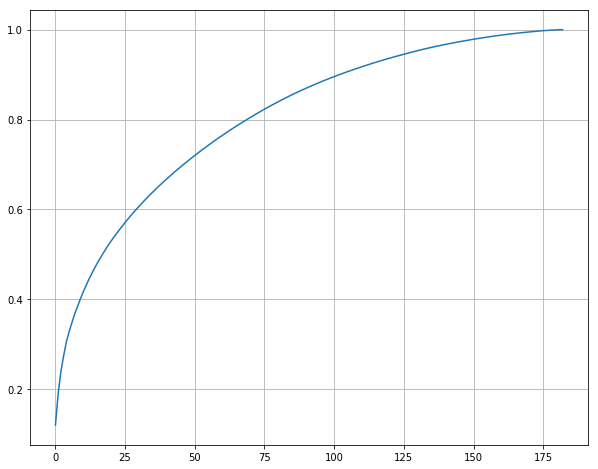

```python
plt.figure(figsize=(10,8))
plt.plot(pca.explained_variance_ratio_.cumsum())
plt.grid(True)
plt.show()
```

as a rule of thumb more than 80% is necessary.So i am taking 100 features so we can get about 90% variance.

```python
pca = PCA(n_components=100)
pca_azdias = pca.fit_transform(azdias_scaled)
pca_azdias = pd.DataFrame(pca_azdias)
```

```python
pca_customers = pca.transform(customers_scaled)
pca_customers = pd.DataFrame(pca_customers)
```

```python
# shape of reduced components
print(pca_azdias.shape)
print(pca_customers.shape)
```

```
(751331, 100)
(135144, 100)
```

```python
pca
```

```
PCA(copy=True, iterated_power='auto', n_components=100, random_state=None,
  svd_solver='auto', tol=0.0, whiten=False)
```

```python
def map_weights(pca, cols, component):
    comp =  pd.DataFrame({'feature names': cols, 'weight': pca.components_[component], 'weight_abs': np.abs(pca.components_[component])})
    return comp.sort_values(by=['weight_abs'], ascending=False)
comp_0 = map_weights(pca, azdias.columns, 0)
comp_0.head()
```

|  | feature names | weight | weight_abs |
| --- | --- | --- | --- |
| 67 | KBA05_SEG6 | 0.205222 | 0.205222 |
| 46 | KBA05_KRSVAN | 0.183296 | 0.183296 |
| 45 | KBA05_KRSOBER | 0.183204 | 0.183204 |
| 47 | KBA05_KRSZUL | 0.176731 | 0.176731 |
| 44 | KBA05_KRSKLEIN | 0.173227 | 0.173227 |

So in Germany share of cars and vans are incresing ike BMW in microcell.

```python
comp_1 = map_weights(pca, azdias.columns, 1)
comp_1.head()
```

|  | feature names | weight | weight_abs |
| --- | --- | --- | --- |
| 182 | OST_WEST_KZ_W | 0.152870 | 0.152870 |
| 181 | OST_WEST_KZ_O | -0.152870 | 0.152870 |
| 20 | HH_EINKOMMEN_SCORE | -0.152530 | 0.152530 |
| 142 | KBA13_SEG_KOMPAKTKLASSE | -0.149681 | 0.149681 |
| 124 | KBA13_KW_0_60 | -0.146195 | 0.146195 |

East Germany are preferably like to own middleclass car as compare to west Germany.

```python
comp_2 = map_weights(pca, azdias.columns, 2)
comp_2.head()
```

|  | feature names | weight | weight_abs |
| --- | --- | --- | --- |
| 10 | EWDICHTE | 0.239087 | 0.239087 |
| 78 | KBA13_ALTERHALTER_60 | -0.220752 | 0.220752 |
| 82 | KBA13_AUTOQUOTE | -0.219402 | 0.219402 |
| 36 | KBA05_GBZ | -0.205203 | 0.205203 |
| 26 | KBA05_ANTG1 | -0.204106 | 0.204106 |

```python
pca_azdias_sample=pca_azdias.sample(20000)
```

```python
wcss=[]
score=[]
for i in range(1,21):
    #print(i)
    kmeans_pca=KMeans(n_clusters=i,init='k-means++',random_state=42)
    model=kmeans_pca.fit(pca_azdias_sample)
    wcss.append(model.inertia_)
```

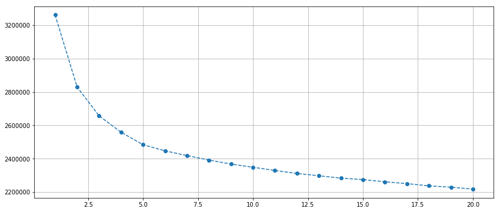

```python
plt.figure(figsize=(14,6))
plt.plot(range(1,21),wcss,marker='o',linestyle='--')
plt.grid(True)
plt.show()
```

I think **5** is right number for KMeans clustering.

```python
kmeans = KMeans(5)
model = kmeans.fit(pca_azdias)
prediction_azdias = model.predict(pca_azdias)
```

```python
print(prediction_azdias)
```

```
[4 3 2 ..., 2 4 2]
```

```python
len(prediction_azdias)
```

```
751331
```

```python
prediction_customers = model.predict(pca_customers)
```

```python
print(prediction_customers)
```

```
[2 3 2 ..., 2 2 2]
```

```python
len(prediction_customers)
```

```
135144
```

```python
cust_dict = {}
for c in set(prediction_customers):
    cust_dict[c] = sum(prediction_customers == c)

print(cust_dict)

y_dict = {}
for c in set(prediction_azdias):
    y_dict[c] = sum(prediction_azdias == c)

print(y_dict)
```

```
{0: 6940, 1: 898, 2: 66098, 3: 45122, 4: 16086}
{0: 119158, 1: 14043, 2: 247426, 3: 148185, 4: 222519}
```

```python
{i: np.where(kmeans.labels_ == i)[0] for i in range(kmeans.n_clusters)}
```

```
{0: array([   145,    147,    148, ..., 751244, 751259, 751263]),
 1: array([    37,     52,    204, ..., 751125, 751152, 751193]),
 2: array([     2,     10,     11, ..., 751326, 751328, 751330]),
 3: array([     1,      3,      4, ..., 751312, 751313, 751322]),
 4: array([     0,      5,      9, ..., 751325, 751327, 751329])}
```

```python
kmeans.labels_
```

```
array([4, 3, 2, ..., 2, 4, 2], dtype=int32)
```

```python
kmeans.n_clusters
```

```
5
```

```python
azdias['labels'] = kmeans.labels_
```

```python
azdias.shape
```

```
(751331, 184)
```

```python
kmeans.labels_.shape
```

```
(751331,)
```

```python
azdias['labels']
```

```
0         4
1         3
2         2
3         3
4         3
5         4
6         3
7         3
8         3
9         4
10        2
11        2
12        3
13        4
14        4
```

[output cut: 47 more lines]

```python
cluster1 = azdias[azdias['labels']==1]
```

```python
cluster1.shape
```

```
(14043, 184)
```

```python
cluster2 = azdias[azdias['labels']==2]
```

```python
cluster2.shape
```

```
(247426, 184)
```

```python
cluster2.describe()
```

|  | ANZ_HAUSHALTE_AKTIV | ANZ_HH_TITEL | ANZ_PERSONEN | ANZ_TITEL | CAMEO_DEUG_2015 | D19_GESAMT_DATUM | D19_GESAMT_OFFLINE_DATUM | D19_TELKO_DATUM | D19_TELKO_OFFLINE_DATUM | D19_TELKO_ONLINE_DATUM | ... | SEMIO_TRADV | SHOPPER_TYP | VERS_TYP | W_KEIT_KIND_HH | WOHNDAUER_2008 | WOHNLAGE | ZABEOTYP | OST_WEST_KZ_O | OST_WEST_KZ_W | labels |
| --- | --- | --- | --- | --- | --- | --- | --- | --- | --- | --- | --- | --- | --- | --- | --- | --- | --- | --- | --- | --- | --- |
| count | 247426.000000 | 247426.000000 | 247426.000000 | 247426.00000 | 247426.000000 | 247426.000000 | 247426.000000 | 247426.000000 | 247426.000000 | 247426.00000 | ... | 247426.000000 | 247426.000000 | 247426.000000 | 247426.000000 | 247426.000000 | 247426.000000 | 247426.000000 | 247426.000000 | 247426.000000 | 247426.0 |
| mean | 2.367706 | 0.006507 | 2.086984 | 0.00268 | 4.034002 | 6.058749 | 8.600208 | 9.242634 | 9.732684 | 9.97459 | ... | 3.604597 | 1.389470 | 1.407002 | 3.740504 | 8.208422 | 4.774167 | 2.864186 | 0.021489 | 0.978511 | 2.0 |
| std | 2.733414 | 0.084281 | 1.317776 | 0.05466 | 1.894874 | 3.287480 | 2.022946 | 1.522939 | 0.933588 | 0.29159 | ... | 1.686580 | 1.143296 | 0.653645 | 1.936054 | 1.688802 | 2.167531 | 1.410104 | 0.145009 | 0.145009 | 0.0 |
| min | 0.000000 | 0.000000 | 0.000000 | 0.00000 | 1.000000 | 1.000000 | 1.000000 | 1.000000 | 1.000000 | 1.00000 | ... | 1.000000 | -1.000000 | -1.000000 | 0.000000 | 1.000000 | 0.000000 | 1.000000 | 0.000000 | 0.000000 | 2.0 |
| 25% | 1.000000 | 0.000000 | 1.000000 | 0.00000 | 3.000000 | 3.000000 | 8.000000 | 9.000000 | 10.000000 | 10.00000 | ... | 2.000000 | 0.000000 | 1.000000 | 2.000000 | 9.000000 | 3.000000 | 1.000000 | 0.000000 | 1.000000 | 2.0 |
| 50% | 2.000000 | 0.000000 | 2.000000 | 0.00000 | 4.000000 | 6.000000 | 9.000000 | 10.000000 | 10.000000 | 10.00000 | ... | 4.000000 | 1.000000 | 1.000000 | 4.000000 | 9.000000 | 4.000000 | 3.000000 | 0.000000 | 1.000000 | 2.0 |
| 75% | 3.000000 | 0.000000 | 3.000000 | 0.00000 | 5.000000 | 9.000000 | 10.000000 | 10.000000 | 10.000000 | 10.00000 | ... | 5.000000 | 2.000000 | 2.000000 | 6.000000 | 9.000000 | 7.000000 | 4.000000 | 0.000000 | 1.000000 | 2.0 |
| max | 157.000000 | 3.000000 | 21.000000 | 2.00000 | 9.000000 | 10.000000 | 10.000000 | 10.000000 | 10.000000 | 10.00000 | ... | 7.000000 | 3.000000 | 2.000000 | 6.000000 | 9.000000 | 8.000000 | 6.000000 | 1.000000 | 1.000000 | 2.0 |

8 rows × 184 columns

```python
cluster1.describe()
```

|  | ANZ_HAUSHALTE_AKTIV | ANZ_HH_TITEL | ANZ_PERSONEN | ANZ_TITEL | CAMEO_DEUG_2015 | D19_GESAMT_DATUM | D19_GESAMT_OFFLINE_DATUM | D19_TELKO_DATUM | D19_TELKO_OFFLINE_DATUM | D19_TELKO_ONLINE_DATUM | ... | SEMIO_TRADV | SHOPPER_TYP | VERS_TYP | W_KEIT_KIND_HH | WOHNDAUER_2008 | WOHNLAGE | ZABEOTYP | OST_WEST_KZ_O | OST_WEST_KZ_W | labels |
| --- | --- | --- | --- | --- | --- | --- | --- | --- | --- | --- | --- | --- | --- | --- | --- | --- | --- | --- | --- | --- | --- |
| count | 14043.000000 | 14043.000000 | 14043.000000 | 14043.000000 | 14043.000000 | 14043.000000 | 14043.000000 | 14043.000000 | 14043.000000 | 14043.000000 | ... | 14043.000000 | 14043.000000 | 14043.000000 | 14043.000000 | 14043.000000 | 14043.000000 | 14043.000000 | 14043.000000 | 14043.000000 | 14043.0 |
| mean | 25.921456 | 0.142847 | 1.210069 | 0.004130 | 7.428968 | 8.705761 | 9.608702 | 9.737805 | 9.943887 | 9.993947 | ... | 3.692017 | 1.492060 | 1.486221 | 4.945240 | 7.826818 | 4.043509 | 3.765435 | 0.331411 | 0.668589 | 1.0 |
| std | 28.804893 | 0.589482 | 0.949377 | 0.070484 | 1.944573 | 2.421304 | 1.171603 | 0.936778 | 0.413917 | 0.127560 | ... | 1.526320 | 1.064769 | 0.802365 | 1.671176 | 1.974608 | 1.633017 | 1.180822 | 0.470737 | 0.470737 | 0.0 |
| min | 0.000000 | 0.000000 | 0.000000 | 0.000000 | 1.000000 | 1.000000 | 1.000000 | 1.000000 | 1.000000 | 5.000000 | ... | 1.000000 | -1.000000 | -1.000000 | 0.000000 | 1.000000 | 0.000000 | 1.000000 | 0.000000 | 0.000000 | 1.0 |
| 25% | 9.000000 | 0.000000 | 1.000000 | 0.000000 | 7.000000 | 9.000000 | 10.000000 | 10.000000 | 10.000000 | 10.000000 | ... | 3.000000 | 1.000000 | 1.000000 | 4.000000 | 8.000000 | 3.000000 | 3.000000 | 0.000000 | 0.000000 | 1.0 |
| 50% | 19.000000 | 0.000000 | 1.000000 | 0.000000 | 8.000000 | 10.000000 | 10.000000 | 10.000000 | 10.000000 | 10.000000 | ... | 4.000000 | 1.000000 | 2.000000 | 6.000000 | 9.000000 | 4.000000 | 3.000000 | 0.000000 | 1.000000 | 1.0 |
| 75% | 33.000000 | 0.000000 | 1.000000 | 0.000000 | 9.000000 | 10.000000 | 10.000000 | 10.000000 | 10.000000 | 10.000000 | ... | 5.000000 | 2.000000 | 2.000000 | 6.000000 | 9.000000 | 5.000000 | 4.000000 | 1.000000 | 1.000000 | 1.0 |
| max | 328.000000 | 15.000000 | 45.000000 | 3.000000 | 9.000000 | 10.000000 | 10.000000 | 10.000000 | 10.000000 | 10.000000 | ... | 7.000000 | 3.000000 | 2.000000 | 6.000000 | 9.000000 | 8.000000 | 6.000000 | 1.000000 | 1.000000 | 1.0 |

8 rows × 184 columns

There is no possible way to compare these clusters.

## Part 2: Supervised Learning Model

Now that we've found which parts of the population are more likely to be customers of the mail-order company, it's time to build a prediction model. Each of the rows in the "MAILOUT" data files represents an individual that was targeted for a mailout campaign. Ideally, we should be able to use the demographic information from each individual to decide whether or not it will be worth it to include that person in the campaign.

The "MAILOUT" data has been split into two approximately equal parts, each with almost 43 000 data rows. In this part, you can verify your model with the "TRAIN" partition, which includes a column, "RESPONSE", that states whether or not a person became a customer of the company following the campaign. In the next part, you'll need to create predictions on the "TEST" partition, where the "RESPONSE" column has been withheld.

```python
import pandas as pd
import numpy as np
import matplotlib.pyplot as plt
import seaborn as sns
from sklearn.model_selection import train_test_split
%matplotlib inline
```

```python
train_dataset = pd.read_csv('../../data/Term2/capstone/arvato_data/Udacity_MAILOUT_052018_TRAIN.csv',sep=';')
```

```python
train_dataset.drop(['CAMEO_DEU_2015', 'CAMEO_DEUG_2015', 'CAMEO_INTL_2015', 'D19_LETZTER_KAUF_BRANCHE', 'EINGEFUEGT_AM','OST_WEST_KZ'],axis=1,inplace=True)
```

```python
X = train_dataset.drop('RESPONSE',axis=1)
y = train_dataset['RESPONSE']
```

```python
X_train,X_test,y_train,y_test = train_test_split(X,y,random_state=42,test_size=0.3)
```

```python
X_train,X_val,y_train,y_val = train_test_split(X_train,y_train,random_state=42,test_size=0.3)
```

```python
import xgboost
from xgboost import XGBRegressor
```

```python
model = XGBRegressor(base_score=0.5, booster='gbtree', colsample_bylevel=1,
       colsample_bytree=0.7, eval_metric='auc', gamma=1.0,
       learning_rate=0.01, max_delta_step=0, max_depth=7,
       min_child_weight=1, missing=None, n_estimators=250, n_jobs=-1,
       nthread=None, objective='binary:logistic', random_state=42,
       reg_alpha=1e-07, reg_lambda=1, scale_pos_weight=1, seed=None,
       silent=1, subsample=0.5)
```

```python
model.fit(X_train,y_train)
```

```
XGBRegressor(base_score=0.5, booster='gbtree', colsample_bylevel=1,
       colsample_bynode=1, colsample_bytree=0.7, eval_metric='auc',
       gamma=1.0, gpu_id=-1, importance_type='gain',
       interaction_constraints=None, learning_rate=0.01, max_delta_step=0,
       max_depth=7, min_child_weight=1, missing=nan,
       monotone_constraints=None, n_estimators=250, n_jobs=-1, nthread=-1,
       num_parallel_tree=1, objective='binary:logistic', random_state=42,
       reg_alpha=1e-07, reg_lambda=1, scale_pos_weight=1, seed=42,
       silent=1, subsample=0.5, tree_method=None,
       validate_parameters=False, verbosity=None)
```

```python
from sklearn.metrics import roc_auc_score
pred_train = model.predict(X_train)
pred_test = model.predict(X_test)
pred_val = model.predict(X_val)
```

```python
roc_auc_score(y_train,pred_train)
```

```
0.92444422494426925
```

```python
roc_auc_score(y_test,pred_test)
```

```
0.77481776819529258
```

```python
roc_auc_score(y_val,pred_val)
```

```
0.78532094146488718
```

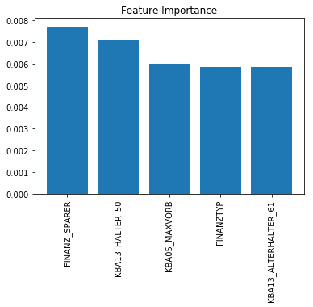

```python
# Calculate feature importances
importances = model.feature_importances_

# Sort feature importances in descending order
indices = np.argsort(importances)[::-1][:5]

# Rearrange feature names so they match the sorted feature importances
names = [X.columns[i] for i in indices][:5]


# Create plot
plt.figure()

# Create plot title
plt.title("Feature Importance")

# Add bars
plt.bar(range(5), importances[indices])

# Add feature names as x-axis labels
plt.xticks(range(5) ,names, rotation=90)

# Show plot
plt.show()
```

## Part 3: Kaggle Competition

```python
testdata = pd.read_csv('../../data/Term2/capstone/arvato_data/Udacity_MAILOUT_052018_TEST.csv', sep=';')
```

```python
testdata.drop(['CAMEO_DEU_2015', 'CAMEO_DEUG_2015', 'CAMEO_INTL_2015', 'D19_LETZTER_KAUF_BRANCHE', 'EINGEFUEGT_AM','OST_WEST_KZ'],axis=1,inplace=True)
```

```python
testpred = model.predict(testdata)
```

```python
kaggle_sub = pd.DataFrame(index=testdata['LNR'].astype('int32'), data=testpred)
kaggle_sub.rename(columns={0: "RESPONSE"}, inplace=True)
kaggle_sub.to_csv('kagglesubmission.csv')
```